# HEIDI: ACHE

[figure not shown]

**Institution Profile**

**Classification:** Special Focus: Medical Schools and Centers

**Size:** Small

**Award Level Focus:** Graduate-focused

**UG Program Mix:** Not classified

**Grad Program Mix:** Special Focus: Medical Schools and Centers

**Research Activity:** No research designation

**Student Access & Earnings:** Not Classified in SAEC

**Top Degree Programs — 2023-24**

| Program | % of Degrees |
| --- | --- |
| Medicine. | 80.6% |
| Biological and Biomedical Sciences, Other. | 19.4% |

**Location**

[interactive chart not shown]

#### Higher Education Institutional Data Interface (HEIDI)

HEIDI is a dashboard tool created by the Casagrande Institute to report data for institutions of higher education.

#### Casagrande Institute

The [Casagrande Institute](https://www.viterbo.edu/casagrande-institute/) helps institutions develop effective compensation practices for executives, faculty, and staff.

**David J. Bauer, Ph.D.**  
Director, Casagrande Institute  
djbauer@viterbo.edu  
608-796-3617  
[LinkedIn](https://www.linkedin.com/in/davidjbauer/)

**Group Overview**

- **AUTO**: Created by IPEDS in 2024-25 based on an internal grouping process involving Level, Control, Carnegie classification, and other variables.
- **ACHE - Test 1**: Subset of AUTO institutions with Revenue under $150M.
- **ACHE - Test 2**: Test group for ACHE including Private NFP Special Focus Medical and Special Focus Other Health, with Revenue from $25M to $150M.
- **ACHE - Test 3**: Test group for ACHE including Private NFP Special Focus Medical institutions minus R1 and R2 institutions.
- **COCA**: Commission on Osteopathic College Accreditation (COCA) institutions, as identified in 2026, and as available in IPEDS.
- **NFP Osteo / Medical**: Group of Private NFP institutions with Expenses up to $500M that satisfy one or more of the following criteria: 1. membership in the American Association of Colleges of Osteopathic Medicine (AACOM) institutions in 2026, 2. membership in the Commission on Osteopathic College Accreditation (COCA) institutions in 2026, or 3. a 2025 Carnegie classification of “Special Focus: Medical Schools and Centers”. Excludes institutions in Puerto Rico.

**Group Membership**

| Institution | AUTO | ACHE - Test 1 | ACHE - Test 2 | ACHE - Test 3 | COCA | NFP Osteo / Medical |
| --- | --- | --- | --- | --- | --- | --- |
| A T Still University of Health Sciences | ✓ |  |  | ✓ | ✓ | ✓ |
| Alabama College of Osteopathic Medicine | ✓ | ✓ | ✓ | ✓ | ✓ | ✓ |
| Albany College of Pharmacy and Health Sciences |  |  | ✓ |  |  |  |
| Albany Medical College | ✓ |  |  | ✓ |  |  |
| Alvernia University |  |  | ✓ |  |  |  |
| Baptist Health Sciences University |  |  |  |  | ✓ | ✓ |
| Bastyr University |  |  | ✓ |  |  |  |
| Bluefield College - Edward Via College of Osteopathic Medicine |  |  |  |  | ✓ |  |
| Bluefield University - Edward Via College - Auburn |  |  |  |  | ✓ |  |
| Burrell College of Osteopathic Medicine |  |  |  |  | ✓ |  |

[output cut: 79 more lines]

**AUTO**

| Name | City | State | Zip | Carnegie | Research | Revenue | Expenses | FTE | Endowment |
| --- | --- | --- | --- | --- | --- | --- | --- | --- | --- |
| A T Still University of Health Sciences | Kirksville | MO | 63501 | Special Focus: Medical Schools and Centers | No research designation | 246784177 | 189842485 | 3923 | 136425451 |
| Alabama College of Osteopathic Medicine | Dothan | AL | 36303 | Special Focus: Medical Schools and Centers | No research designation | 48551065 | 35147162 | 799 | 217663 |
| Albany Medical College | Albany | NY | 12208 | Special Focus: Medical Schools and Centers | Research Colleges and Universities | 479805000 | 505460000 | 900 | 130749000 |
| Arkansas Colleges of Health Education | Fort Smith | AR | 72916 | Special Focus: Medical Schools and Centers | No research designation | 57982168 | 47269642 | 907 | 6636048 |
| California University of Science and Medicine | Colton | CA | 92324 | Special Focus: Graduate Studies | No research designation | 43139388 | 42561834 | 564 |  |
| Des Moines University-Osteopathic Medical Center | West Des Moines | IA | 50266 | Special Focus: Medical Schools and Centers | Research Colleges and Universities | 99479413 | 89508356 | 1639 | 177057947 |
| Edward Via College of Osteopathic Medicine | Blacksburg | VA | 24060 | Special Focus: Medical Schools and Centers | Research Colleges and Universities | 153360525 | 120866047 | 2615 | 31210043 |
| Geisinger Commonwealth School of Medicine | Scranton | PA | 18509 | Special Focus: Medical Schools and Centers | No research designation | 50098356 | 44681781 | 659 | 5959058 |
| Kansas City University | Kansas City | MO | 64106 | Special Focus: Medical Schools and Centers | No research designation | 144820393 | 98494227 | 1997 | 35910011 |
| Lake Erie College of Osteopathic Medicine | Erie | PA | 16509 | Special Focus: Medical Schools and Centers | No research designation | 270050867 | 124109207 | 4415 | 5029560 |

[output cut: 13 more lines]

**ACHE - Test 1**

| Name | City | State | Zip | Carnegie | Research | Revenue | Expenses | FTE | Endowment |
| --- | --- | --- | --- | --- | --- | --- | --- | --- | --- |
| Alabama College of Osteopathic Medicine | Dothan | AL | 36303 | Special Focus: Medical Schools and Centers | No research designation | 48551065 | 35147162 | 799 | 217663 |
| Arkansas Colleges of Health Education | Fort Smith | AR | 72916 | Special Focus: Medical Schools and Centers | No research designation | 57982168 | 47269642 | 907 | 6636048 |
| California University of Science and Medicine | Colton | CA | 92324 | Special Focus: Graduate Studies | No research designation | 43139388 | 42561834 | 564 |  |
| Des Moines University-Osteopathic Medical Center | West Des Moines | IA | 50266 | Special Focus: Medical Schools and Centers | Research Colleges and Universities | 99479413 | 89508356 | 1639 | 177057947 |
| Geisinger Commonwealth School of Medicine | Scranton | PA | 18509 | Special Focus: Medical Schools and Centers | No research designation | 50098356 | 44681781 | 659 | 5959058 |
| Kansas City University | Kansas City | MO | 64106 | Special Focus: Medical Schools and Centers | No research designation | 144820393 | 98494227 | 1997 | 35910011 |
| New York Medical College | Valhalla | NY | 10595 | Special Focus: Medical Schools and Centers | Research Colleges and Universities | 128228436 | 117714575 | 1401 | 81415365 |
| Pacific Northwest University of Health Sciences | Yakima | WA | 98901 | Special Focus: Medical Schools and Centers | No research designation | 50719884 | 43709889 | 668 | 2641142 |
| Rosalind Franklin University of Medicine and Science | North Chicago | IL | 60064 | Special Focus: Medical Schools and Centers | Research Colleges and Universities | 140327821 | 148631519 | 2388 | 85623041 |
| Touro University California | Vallejo | CA | 94592 | Special Focus: Medical Schools and Centers | Research Colleges and Universities | 78452346 | 83139930 | 1229 |  |

[output cut: 2 more lines]

**ACHE - Test 2**

| Name | City | State | Zip | Carnegie | Research | Revenue | Expenses | FTE | Endowment |
| --- | --- | --- | --- | --- | --- | --- | --- | --- | --- |
| Alabama College of Osteopathic Medicine | Dothan | AL | 36303 | Special Focus: Medical Schools and Centers | No research designation | 48551065 | 35147162 | 799 | 217663 |
| Albany College of Pharmacy and Health Sciences | Albany | NY | 12208 | Special Focus: Other Health Professions | Research Colleges and Universities | 54036995 | 54881276 | 912 | 68029602 |
| Alvernia University | Reading | PA | 19607 | Special Focus: Other Health Professions | No research designation | 75416015 | 72608610 | 2395 | 18457597 |
| Arkansas Colleges of Health Education | Fort Smith | AR | 72916 | Special Focus: Medical Schools and Centers | No research designation | 57982168 | 47269642 | 907 | 6636048 |
| Bastyr University | Kenmore | WA | 98028 | Special Focus: Other Health Professions | No research designation | 29188278 | 34530430 | 639 | 762289 |
| Carlow University | Pittsburgh | PA | 15213 | Special Focus: Other Health Professions | No research designation | 67804056 | 68910556 | 2060 | 56831178 |
| Charles R Drew University of Medicine and Science | Los Angeles | CA | 90059 | Special Focus: Medical Schools and Centers | Research Colleges and Universities | 95118100 | 96581000 | 1197 | 109922800 |
| College of Saint Mary | Omaha | NE | 68106 | Special Focus: Other Health Professions | No research designation | 26672542 | 30186983 | 728 | 32085539 |
| D'Youville University | Buffalo | NY | 14201 | Special Focus: Other Health Professions | No research designation | 86480172 | 95298826 | 2412 | 22307551 |
| Des Moines University-Osteopathic Medical Center | West Des Moines | IA | 50266 | Special Focus: Medical Schools and Centers | Research Colleges and Universities | 99479413 | 89508356 | 1639 | 177057947 |

[output cut: 35 more lines]

**ACHE - Test 3**

| Name | City | State | Zip | Carnegie | Research | Revenue | Expenses | FTE | Endowment |
| --- | --- | --- | --- | --- | --- | --- | --- | --- | --- |
| A T Still University of Health Sciences | Kirksville | MO | 63501 | Special Focus: Medical Schools and Centers | No research designation | 246784177 | 189842485 | 3923 | 136425451 |
| Alabama College of Osteopathic Medicine | Dothan | AL | 36303 | Special Focus: Medical Schools and Centers | No research designation | 48551065 | 35147162 | 799 | 217663 |
| Albany Medical College | Albany | NY | 12208 | Special Focus: Medical Schools and Centers | Research Colleges and Universities | 479805000 | 505460000 | 900 | 130749000 |
| Arkansas Colleges of Health Education | Fort Smith | AR | 72916 | Special Focus: Medical Schools and Centers | No research designation | 57982168 | 47269642 | 907 | 6636048 |
| Charles R Drew University of Medicine and Science | Los Angeles | CA | 90059 | Special Focus: Medical Schools and Centers | Research Colleges and Universities | 95118100 | 96581000 | 1197 | 109922800 |
| Des Moines University-Osteopathic Medical Center | West Des Moines | IA | 50266 | Special Focus: Medical Schools and Centers | Research Colleges and Universities | 99479413 | 89508356 | 1639 | 177057947 |
| Edward Via College of Osteopathic Medicine | Blacksburg | VA | 24060 | Special Focus: Medical Schools and Centers | Research Colleges and Universities | 153360525 | 120866047 | 2615 | 31210043 |
| Geisinger Commonwealth School of Medicine | Scranton | PA | 18509 | Special Focus: Medical Schools and Centers | No research designation | 50098356 | 44681781 | 659 | 5959058 |
| Hackensack Meridian School of Medicine | Nutley | NJ | 07110 | Special Focus: Medical Schools and Centers | No research designation | 59413187 | 37958759 | 570 | 142923967 |
| Kansas City University | Kansas City | MO | 64106 | Special Focus: Medical Schools and Centers | No research designation | 144820393 | 98494227 | 1997 | 35910011 |

[output cut: 19 more lines]

**COCA**

| Name | City | State | Zip | Control | Carnegie | Research | Revenue | Expenses | FTE | Endowment |
| --- | --- | --- | --- | --- | --- | --- | --- | --- | --- | --- |
| A T Still University of Health Sciences | Kirksville | MO | 63501 | Private NFP | Special Focus: Medical Schools and Centers | No research designation | 246784177 | 189842485 | 3923 | 136425451 |
| Alabama College of Osteopathic Medicine | Dothan | AL | 36303 | Private NFP | Special Focus: Medical Schools and Centers | No research designation | 48551065 | 35147162 | 799 | 217663 |
| Arkansas Colleges of Health Education | Fort Smith | AR | 72916 | Private NFP | Special Focus: Medical Schools and Centers | No research designation | 57982168 | 47269642 | 907 | 6636048 |
| Baptist Health Sciences University | Memphis | TN | 38104 | Private NFP | Special Focus: Nursing | No research designation | 34109038 | 30432074 | 622 | 91778586 |
| Bluefield University - Edward Via College - Auburn | Auburn | AL | 36832 | Not Available | Not classified | No research designation |  |  | 0 |  |
| Burrell College of Osteopathic Medicine | Las Cruces | NM | 88001 | Private For-Profit | Special Focus: Medical Schools and Centers | No research designation |  |  | 687 |  |
| California Health Sciences University | Clovis | CA | 93612 | Private For-Profit | Special Focus: Medical Schools and Centers | No research designation |  |  | 527 |  |
| Campbell University | Buies Creek | NC | 27506 | Private NFP | Professions-focused Undergraduate/Graduate-Doctorate Medium | No research designation | 186676855 | 161912512 | 5172 | 210406971 |
| D'Youville University | Buffalo | NY | 14201 | Private NFP | Special Focus: Other Health Professions | No research designation | 86480172 | 95298826 | 2412 | 22307551 |
| Des Moines University-Osteopathic Medical Center | West Des Moines | IA | 50266 | Private NFP | Special Focus: Medical Schools and Centers | Research Colleges and Universities | 99479413 | 89508356 | 1639 | 177057947 |

[output cut: 33 more lines]

**NFP Osteo / Medical**

| Name | City | State | Zip | Carnegie | Research | Revenue | Expenses | FTE | Endowment |
| --- | --- | --- | --- | --- | --- | --- | --- | --- | --- |
| A T Still University of Health Sciences | Kirksville | MO | 63501 | Special Focus: Medical Schools and Centers | No research designation | 246784177 | 189842485 | 3923 | 136425451 |
| Alabama College of Osteopathic Medicine | Dothan | AL | 36303 | Special Focus: Medical Schools and Centers | No research designation | 48551065 | 35147162 | 799 | 217663 |
| Arkansas Colleges of Health Education | Fort Smith | AR | 72916 | Special Focus: Medical Schools and Centers | No research designation | 57982168 | 47269642 | 907 | 6636048 |
| Baptist Health Sciences University | Memphis | TN | 38104 | Special Focus: Nursing | No research designation | 34109038 | 30432074 | 622 | 91778586 |
| Campbell University | Buies Creek | NC | 27506 | Professions-focused Undergraduate/Graduate-Doctorate Medium | No research designation | 186676855 | 161912512 | 5172 | 210406971 |
| Charles R Drew University of Medicine and Science | Los Angeles | CA | 90059 | Special Focus: Medical Schools and Centers | Research Colleges and Universities | 95118100 | 96581000 | 1197 | 109922800 |
| D'Youville University | Buffalo | NY | 14201 | Special Focus: Other Health Professions | No research designation | 86480172 | 95298826 | 2412 | 22307551 |
| Des Moines University-Osteopathic Medical Center | West Des Moines | IA | 50266 | Special Focus: Medical Schools and Centers | Research Colleges and Universities | 99479413 | 89508356 | 1639 | 177057947 |
| Duquesne University | Pittsburgh | PA | 15282 | Professions-focused Undergraduate/Graduate-Doctorate Medium | Research 2: High Spending and Doctorate Production | 382314000 | 323172000 | 8122 | 661012000 |
| Edward Via College of Osteopathic Medicine | Blacksburg | VA | 24060 | Special Focus: Medical Schools and Centers | Research Colleges and Universities | 153360525 | 120866047 | 2615 | 31210043 |

[output cut: 29 more lines]

**AUTO**

**Financial and Student Positioning of ACHE Within the AUTO Group**

| Metric | **AUTO Group** n | **AUTO Group** Min | **AUTO Group** p25 | **AUTO Group** Median | **AUTO Group** p75 | **AUTO Group** Max | Spread | **ACHE** ACHE | **ACHE** Percentile | **ACHE** % of Median |
| --- | --- | --- | --- | --- | --- | --- | --- | --- | --- | --- |
| Revenue | 22 | 43.1M | 83.7M | 149.1M | 264.2M | 3.2B |  | 58.0M | 16 | 39% |
| Revenue from Tuition and Fees | 22 | 18.2M | 40.5M | 70.0M | 139.8M | 260.1M |  | 36.7M | 17 | 52% |
| Expenses | 22 | 35.1M | 84.7M | 124.0M | 188.8M | 3.1B |  | 47.3M | 15 | 38% |
| Margin | 22 | −25.7M | 5.7M | 12.0M | 54.3M | 145.9M |  | 10.7M | 48 | 90% |
| Endowment | 20 | 217.7k | 6.2M | 75.2M | 149.2M | 905.8M |  | 6.6M | 29 | 9% |
| 12-Month Unduplicated Headcount | 22 | 361 | 942 | 1,818 | 3,120 | 4,251 |  | 895 | 23 | 49% |
| Undergrad FTE | 4 | 10 | 20 | 49 | 83 | 108 |  | NA | NA | NA |
| Grad FTE | 20 | 8 | 251 | 440 | 733 | 2,092 |  | 54 | 9 | 12% |
| Doc Prof Prac FTE | 22 | 353 | 614 | 1,020 | 2,122 | 3,941 |  | 853 | 44 | 84% |
| Total FTE | 22 | 361 | 921 | 1,681 | 2,881 | 4,415 |  | 907 | 24 | 54% |
| Program Breadth (distinct 4-digit CIPs) | 22 | 1 | 2 | 8 | 11 | 16 |  | 2 | 17 | 25% |
| Top 5 Programs % of Completions | 22 | 68 | 81 | 94 | 100 | 100 |  | 100 | 83 | 106% |
| Distinct Award Levels Offered | 22 | 1 | 2 | 3 | 5 | 6 |  | 2 | 24 | 67% |

Data from IPEDS for the 2024-25 academic year. Group values exclude data from ACHE.

**ACHE - Test 1**

**Financial and Student Positioning of ACHE Within the ACHE - Test 1 Group**

| Metric | **ACHE - Test 1 Group** n | **ACHE - Test 1 Group** Min | **ACHE - Test 1 Group** p25 | **ACHE - Test 1 Group** Median | **ACHE - Test 1 Group** p75 | **ACHE - Test 1 Group** Max | Spread | **ACHE** ACHE | **ACHE** Percentile | **ACHE** % of Median |
| --- | --- | --- | --- | --- | --- | --- | --- | --- | --- | --- |
| Revenue | 11 | 43.1M | 50.4M | 78.5M | 129.4M | 144.8M |  | 58.0M | 33 | 74% |
| Revenue from Tuition and Fees | 11 | 18.2M | 36.4M | 55.0M | 70.0M | 109.9M |  | 36.7M | 26 | 67% |
| Expenses | 11 | 35.1M | 44.2M | 83.1M | 108.1M | 148.6M |  | 47.3M | 31 | 57% |
| Margin | 11 | −8.3M | 3.0M | 6.7M | 10.2M | 46.3M |  | 10.7M | 81 | 160% |
| Endowment | 9 | 217.7k | 6.0M | 35.9M | 85.6M | 177.1M |  | 6.6M | 38 | 18% |
| 12-Month Unduplicated Headcount | 11 | 361 | 734 | 1,208 | 1,818 | 2,200 |  | 895 | 42 | 74% |
| Undergrad FTE | 2 | 23 | 36 | 49 | 62 | 75 |  | NA | NA | NA |
| Grad FTE | 10 | 8 | 74 | 230 | 470 | 725 |  | 54 | 19 | 23% |
| Doc Prof Prac FTE | 11 | 353 | 564 | 799 | 1,174 | 1,859 |  | 853 | 53 | 107% |
| Total FTE | 11 | 361 | 664 | 1,229 | 1,681 | 2,388 |  | 907 | 43 | 74% |
| Program Breadth (distinct 4-digit CIPs) | 11 | 1 | 2 | 4 | 8 | 16 |  | 2 | 25 | 50% |
| Top 5 Programs % of Completions | 11 | 79 | 92 | 100 | 100 | 100 |  | 100 | 75 | 100% |
| Distinct Award Levels Offered | 11 | 1 | 2 | 2 | 4 | 5 |  | 2 | 35 | 100% |

Data from IPEDS for the 2024-25 academic year. Group values exclude data from ACHE.

**ACHE - Test 2**

**Financial and Student Positioning of ACHE Within the ACHE - Test 2 Group**

| Metric | **ACHE - Test 2 Group** n | **ACHE - Test 2 Group** Min | **ACHE - Test 2 Group** p25 | **ACHE - Test 2 Group** Median | **ACHE - Test 2 Group** p75 | **ACHE - Test 2 Group** Max | Spread | **ACHE** ACHE | **ACHE** Percentile | **ACHE** % of Median |
| --- | --- | --- | --- | --- | --- | --- | --- | --- | --- | --- |
| Revenue | 44 | 25.4M | 37.3M | 57.8M | 88.4M | 144.8M |  | 58.0M | 50 | 100% |
| Revenue from Tuition and Fees | 44 | 5.3M | 22.3M | 33.9M | 58.0M | 114.2M |  | 36.7M | 52 | 108% |
| Expenses | 44 | 21.7M | 35.0M | 54.7M | 84.7M | 148.6M |  | 47.3M | 43 | 86% |
| Margin | 44 | −8.8M | −1.2M | 4.3M | 8.2M | 46.3M |  | 10.7M | 86 | 252% |
| Endowment | 41 | 217.7k | 11.2M | 34.6M | 68.0M | 177.1M |  | 6.6M | 21 | 19% |
| 12-Month Unduplicated Headcount | 44 | 361 | 735 | 1,468 | 2,632 | 9,845 |  | 895 | 36 | 61% |
| Undergrad FTE | 28 | 23 | 288 | 596 | 1,543 | 3,564 |  | NA | NA | NA |
| Grad FTE | 39 | 3 | 78 | 194 | 500 | 2,451 |  | 54 | 19 | 28% |
| Doc Prof Prac FTE | 38 | 19 | 338 | 537 | 865 | 2,468 |  | 853 | 75 | 159% |
| Total FTE | 44 | 361 | 652 | 1,400 | 2,056 | 4,794 |  | 907 | 39 | 65% |
| Program Breadth (distinct 4-digit CIPs) | 44 | 1 | 3 | 8 | 22 | 55 |  | 2 | 14 | 27% |
| Top 5 Programs % of Completions | 44 | 53 | 77 | 94 | 100 | 100 |  | 100 | 80 | 106% |
| Distinct Award Levels Offered | 44 | 1 | 2 | 4 | 6 | 9 |  | 2 | 19 | 44% |

Data from IPEDS for the 2024-25 academic year. Group values exclude data from ACHE.

**ACHE - Test 3**

**Financial and Student Positioning of ACHE Within the ACHE - Test 3 Group**

| Metric | **ACHE - Test 3 Group** n | **ACHE - Test 3 Group** Min | **ACHE - Test 3 Group** p25 | **ACHE - Test 3 Group** Median | **ACHE - Test 3 Group** p75 | **ACHE - Test 3 Group** Max | Spread | **ACHE** ACHE | **ACHE** Percentile | **ACHE** % of Median |
| --- | --- | --- | --- | --- | --- | --- | --- | --- | --- | --- |
| Revenue | 28 | 16.7M | 69.6M | 135.4M | 239.6M | 479.8M |  | 58.0M | 22 | 43% |
| Revenue from Tuition and Fees | 28 | 12.4M | 32.2M | 65.4M | 132.8M | 260.1M |  | 36.7M | 28 | 56% |
| Expenses | 28 | 13.6M | 78.9M | 120.4M | 180.7M | 505.5M |  | 47.3M | 19 | 39% |
| Margin | 28 | −98.5M | 3.1M | 11.7M | 36.0M | 145.9M |  | 10.7M | 48 | 91% |
| Endowment | 26 | 217.7k | 6.9M | 75.2M | 140.2M | 1.0B |  | 6.6M | 22 | 9% |
| 12-Month Unduplicated Headcount | 28 | 361 | 877 | 1,682 | 2,976 | 6,256 |  | 895 | 26 | 53% |
| Undergrad FTE | 10 | 10 | 71 | 186 | 665 | 2,872 |  | NA | NA | NA |
| Grad FTE | 25 | 8 | 138 | 464 | 756 | 1,867 |  | 54 | 9 | 12% |
| Doc Prof Prac FTE | 28 | 73 | 544 | 850 | 2,078 | 3,941 |  | 853 | 50 | 100% |
| Total FTE | 28 | 361 | 875 | 1,655 | 2,976 | 5,658 |  | 907 | 26 | 55% |
| Program Breadth (distinct 4-digit CIPs) | 28 | 1 | 4 | 6 | 11 | 40 |  | 2 | 15 | 31% |
| Top 5 Programs % of Completions | 28 | 66 | 82 | 96 | 100 | 100 |  | 100 | 80 | 105% |
| Distinct Award Levels Offered | 28 | 1 | 2 | 3 | 5 | 9 |  | 2 | 20 | 67% |

Data from IPEDS for the 2024-25 academic year. Group values exclude data from ACHE.

**COCA**

**Financial and Student Positioning of ACHE Within the COCA Group**

| Metric | **COCA Group** n | **COCA Group** Min | **COCA Group** p25 | **COCA Group** Median | **COCA Group** p75 | **COCA Group** Max | Spread | **ACHE** ACHE | **ACHE** Percentile | **ACHE** % of Median |
| --- | --- | --- | --- | --- | --- | --- | --- | --- | --- | --- |
| Revenue | 37 | 16.2M | 99.5M | 232.5M | 339.5M | 3.7B |  | 58.0M | 9 | 25% |
| Revenue from Tuition and Fees | 37 | 12.7M | 56.1M | 141.9M | 203.4M | 1.0B |  | 36.7M | 11 | 26% |
| Expenses | 37 | 26.0M | 89.5M | 181.7M | 310.7M | 3.3B |  | 47.3M | 9 | 26% |
| Margin | 37 | −9.8M | 7.0M | 28.8M | 59.0M | 455.5M |  | 10.7M | 29 | 37% |
| Endowment | 35 | 217.7k | 26.8M | 91.8M | 200.6M | 5.0B |  | 6.6M | 16 | 7% |
| 12-Month Unduplicated Headcount | 41 | 227 | 1,657 | 3,191 | 8,798 | 143,337 |  | 895 | 16 | 28% |
| Undergrad FTE | 23 | 10 | 1,255 | 3,268 | 6,454 | 47,890 |  | NA | NA | NA |
| Grad FTE | 34 | 16 | 507 | 910 | 1,615 | 37,738 |  | 54 | 3 | 6% |
| Doc Prof Prac FTE | 41 | 19 | 687 | 1,286 | 2,144 | 5,417 |  | 853 | 36 | 66% |
| Total FTE | 42 | 0 | 1,317 | 3,048 | 6,437 | 87,775 |  | 907 | 20 | 30% |
| Program Breadth (distinct 4-digit CIPs) | 40 | 1 | 6 | 11 | 49 | 141 |  | 2 | 15 | 18% |
| Top 5 Programs % of Completions | 40 | 20 | 46 | 77 | 99 | 100 |  | 100 | 88 | 130% |
| Distinct Award Levels Offered | 40 | 1 | 2 | 4 | 6 | 10 |  | 2 | 21 | 50% |

Data from IPEDS for the 2024-25 academic year. Group values exclude data from ACHE.  
This group includes 8 public institutions. Public institutions report finances to IPEDS under GASB accounting standards (Finance form F1A); private not-for-profits report under FASB (form F2). Financial metrics are drawn from the corresponding form and are comparable in concept but not identical in accounting treatment. Public institutions' Revenue (and therefore Margin) includes state appropriations.

**NFP Osteo / Medical**

**Financial and Student Positioning of ACHE Within the NFP Osteo / Medical Group**

| Metric | **NFP Osteo / Medical Group** n | **NFP Osteo / Medical Group** Min | **NFP Osteo / Medical Group** p25 | **NFP Osteo / Medical Group** Median | **NFP Osteo / Medical Group** p75 | **NFP Osteo / Medical Group** Max | Spread | **ACHE** ACHE | **ACHE** Percentile | **ACHE** % of Median |
| --- | --- | --- | --- | --- | --- | --- | --- | --- | --- | --- |
| Revenue | 38 | 16.2M | 80.5M | 149.1M | 245.3M | 438.9M |  | 58.0M | 16 | 39% |
| Revenue from Tuition and Fees | 38 | 12.7M | 44.8M | 85.5M | 167.5M | 303.8M |  | 36.7M | 20 | 43% |
| Expenses | 38 | 26.0M | 84.7M | 124.0M | 188.8M | 426.2M |  | 47.3M | 14 | 38% |
| Margin | 38 | −98.5M | 6.5M | 18.6M | 32.3M | 145.9M |  | 10.7M | 38 | 58% |
| Endowment | 36 | 217.7k | 33.3M | 83.5M | 173.4M | 1.0B |  | 6.6M | 16 | 8% |
| 12-Month Unduplicated Headcount | 38 | 227 | 1,137 | 2,404 | 4,585 | 14,626 |  | 895 | 15 | 37% |
| Undergrad FTE | 20 | 10 | 425 | 1,255 | 2,971 | 5,602 |  | NA | NA | NA |
| Grad FTE | 33 | 8 | 370 | 725 | 1,047 | 3,808 |  | 54 | 4 | 7% |
| Doc Prof Prac FTE | 38 | 19 | 584 | 1,020 | 1,835 | 3,941 |  | 853 | 42 | 84% |
| Total FTE | 38 | 227 | 1,134 | 2,346 | 4,088 | 10,757 |  | 907 | 18 | 39% |
| Program Breadth (distinct 4-digit CIPs) | 37 | 1 | 5 | 11 | 34 | 66 |  | 2 | 11 | 18% |
| Top 5 Programs % of Completions | 37 | 40 | 68 | 85 | 100 | 100 |  | 100 | 88 | 118% |
| Distinct Award Levels Offered | 37 | 1 | 3 | 4 | 6 | 11 |  | 2 | 15 | 50% |

Data from IPEDS for the 2024-25 academic year. Group values exclude data from ACHE.

**AUTO**

**Revenue**

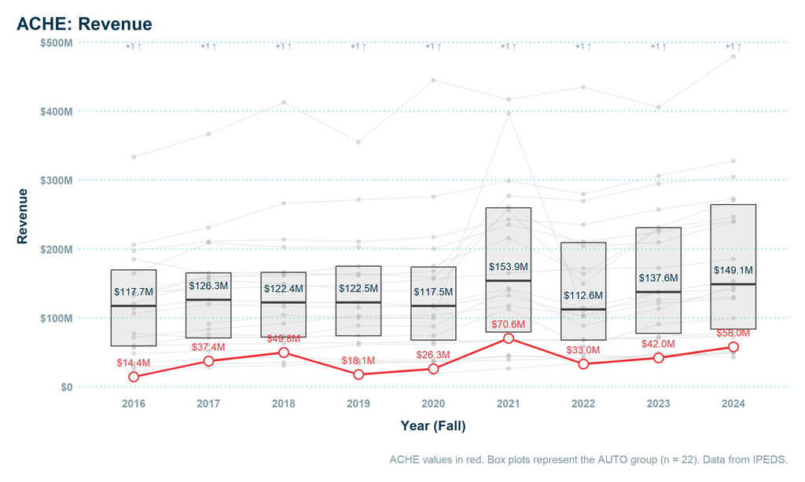

**Revenue from Tuition and Fees**

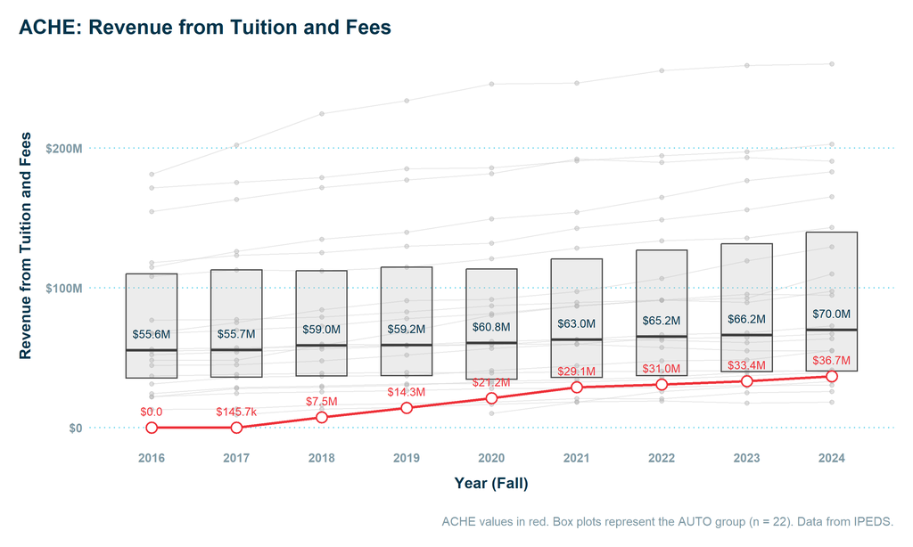

**Expenses**

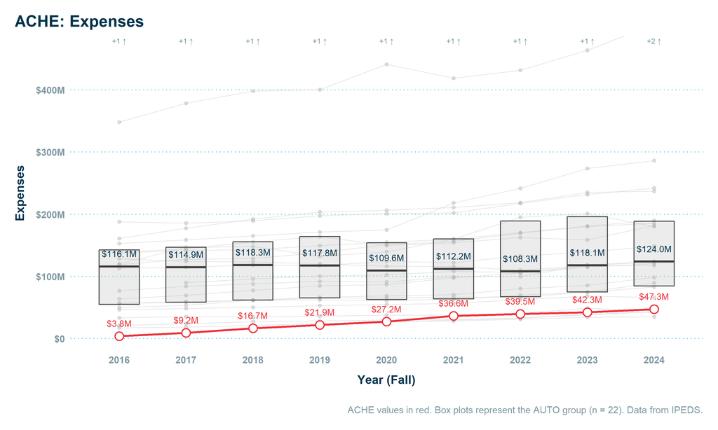

**Margin**

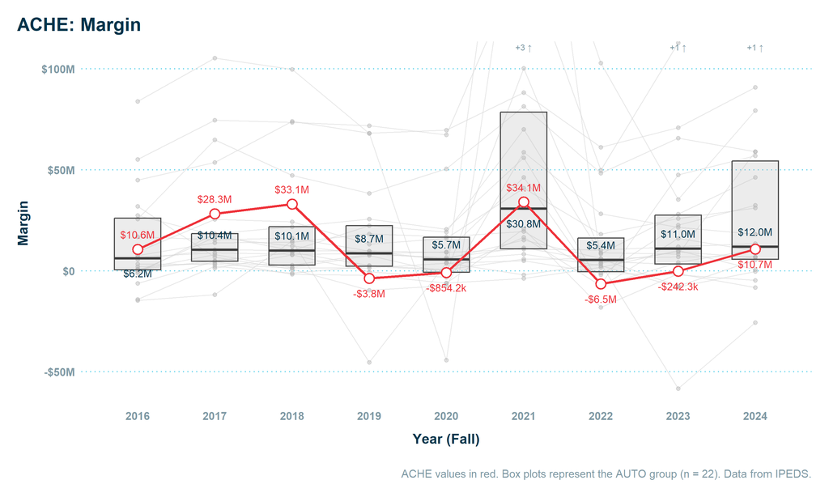

**Endowment**

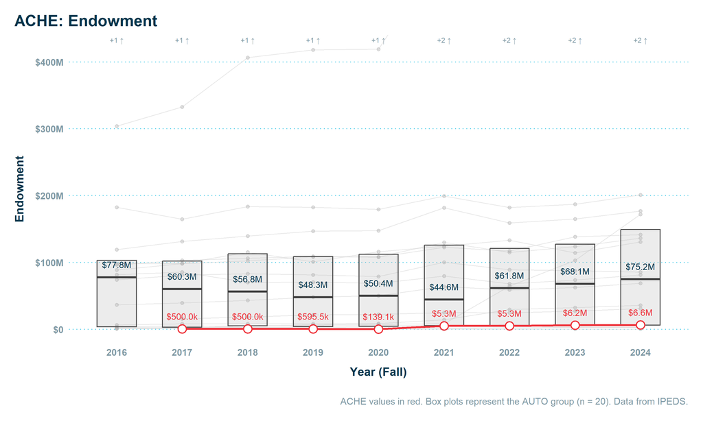

**12-Month Unduplicated Headcount**

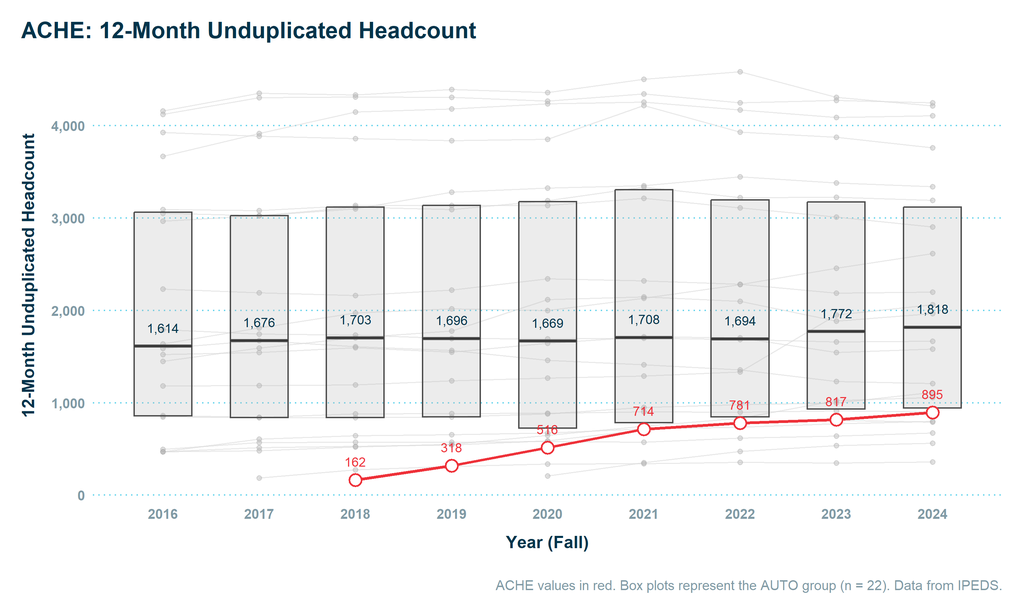

**Undergrad FTE**

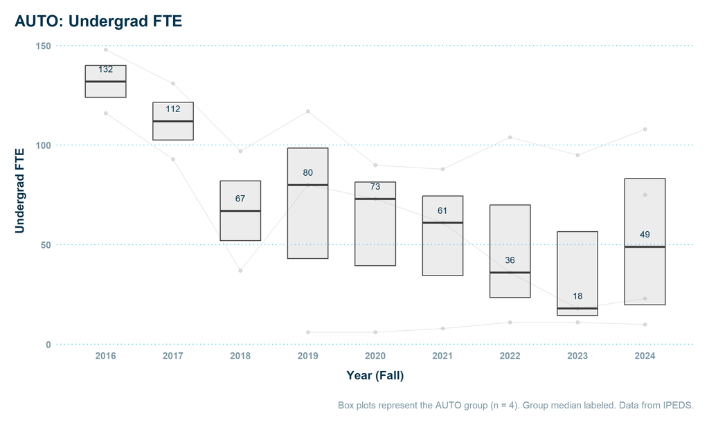

**Grad FTE**

[figure not shown]

**Doc Prof Prac FTE**

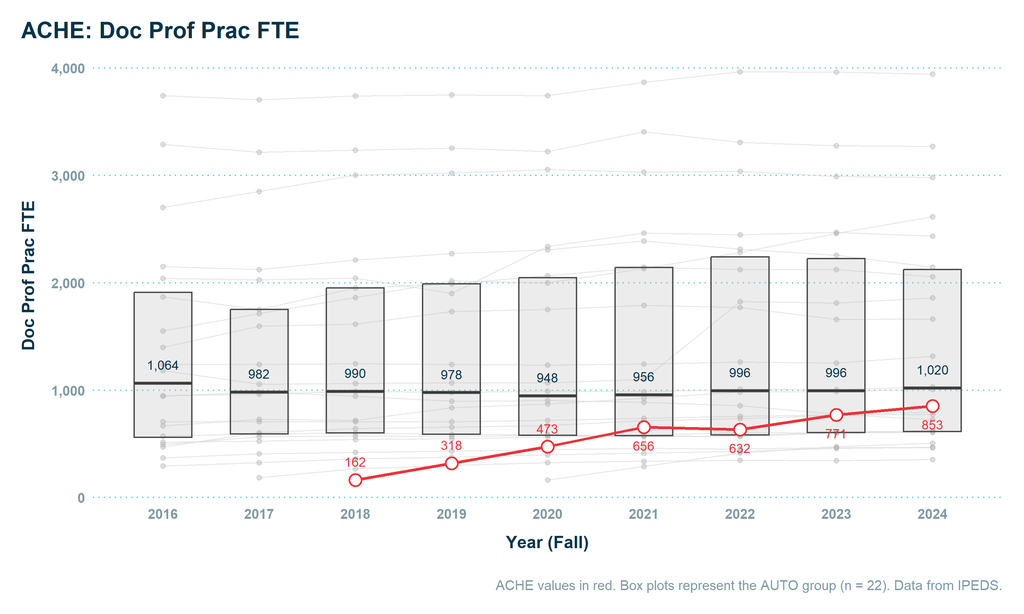

**Total FTE**

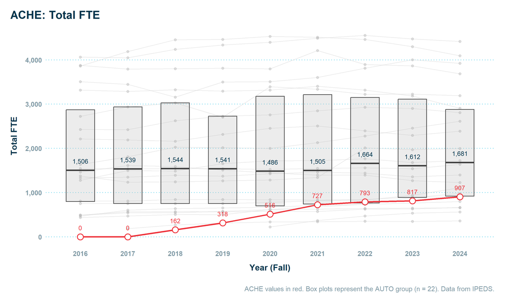

**Program Breadth (distinct 4-digit CIPs)**

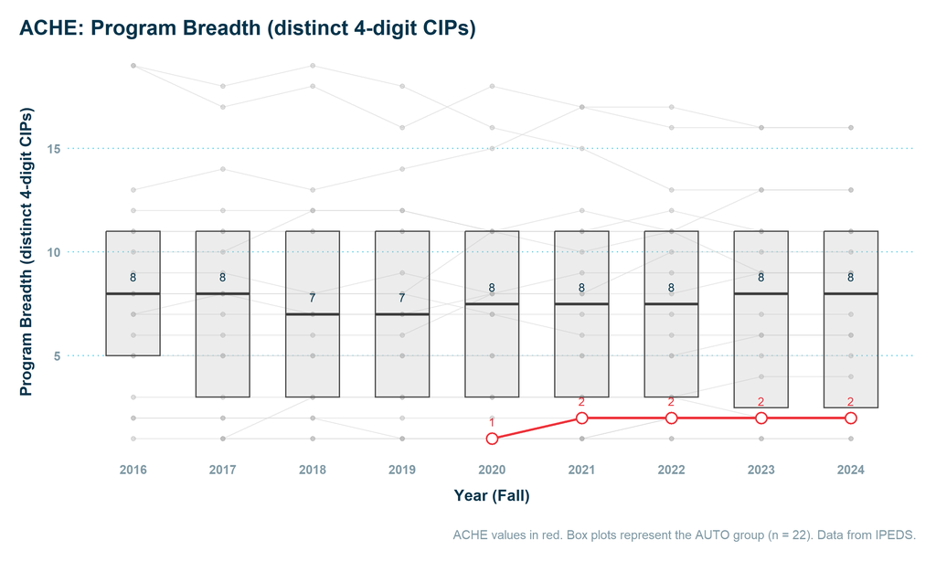

**Top 5 Programs % of Completions**

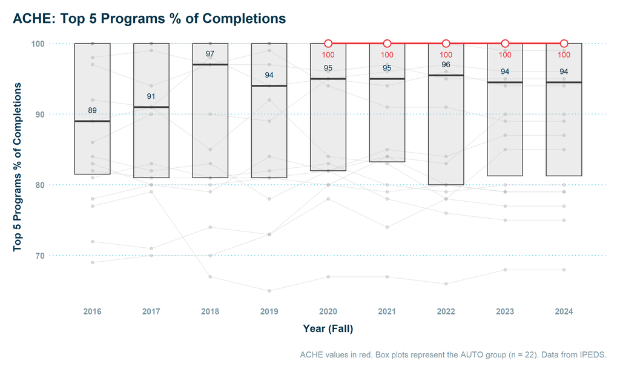

**Distinct Award Levels Offered**

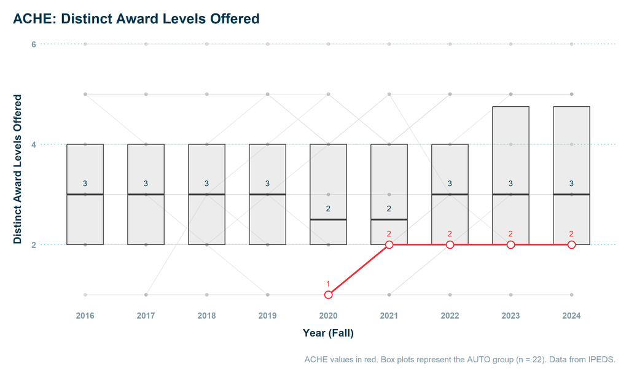

**ACHE - Test 1**

**Revenue**

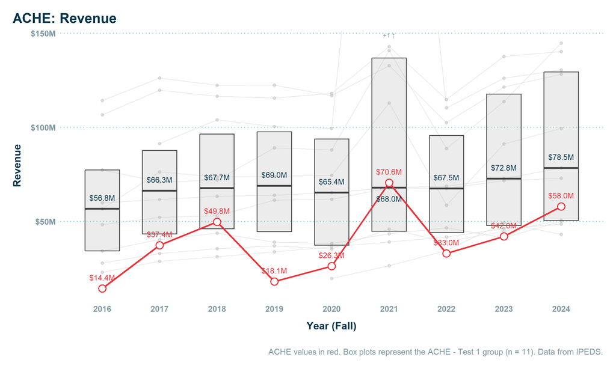

**Revenue from Tuition and Fees**

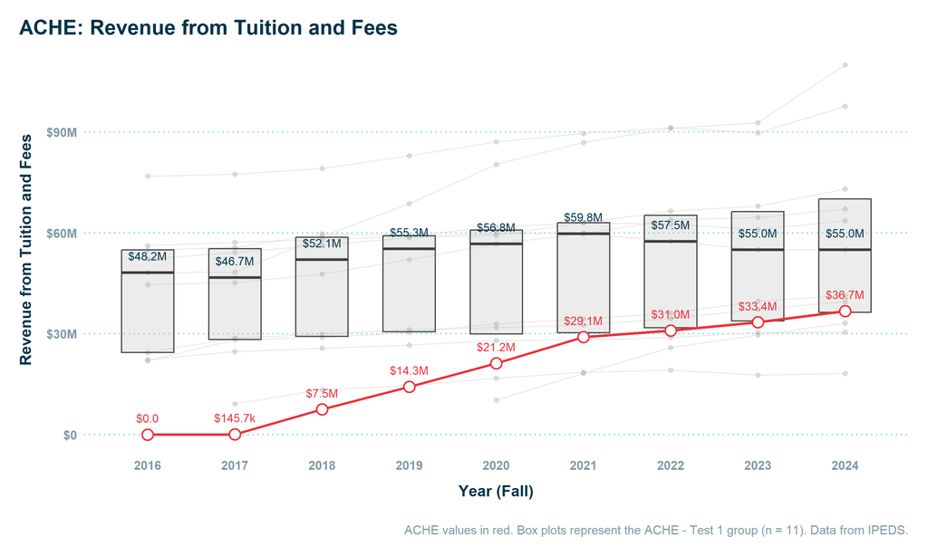

**Expenses**

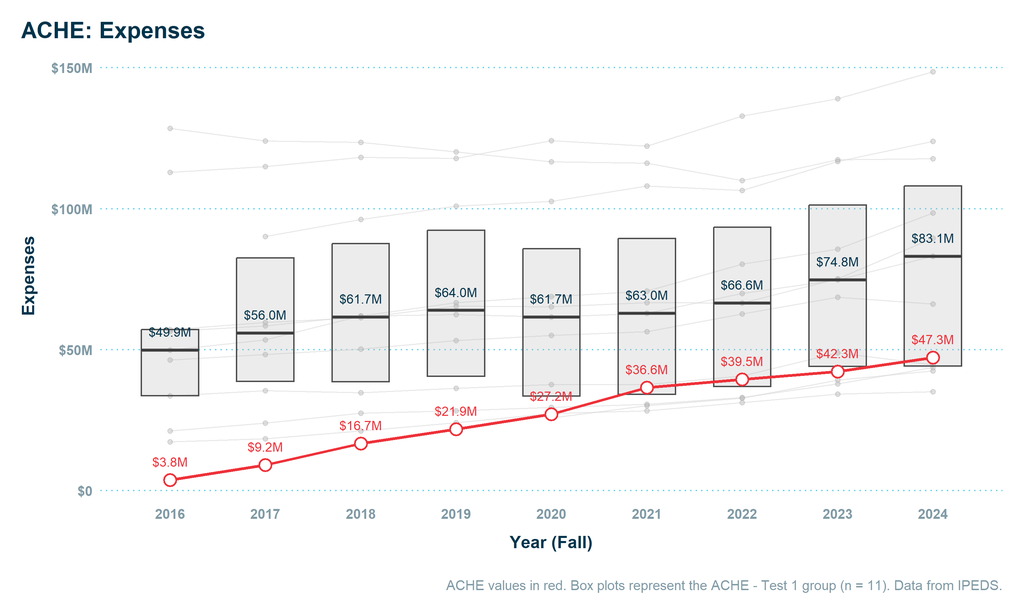

**Margin**

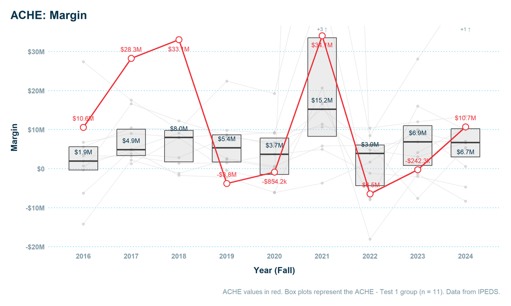

**Endowment**

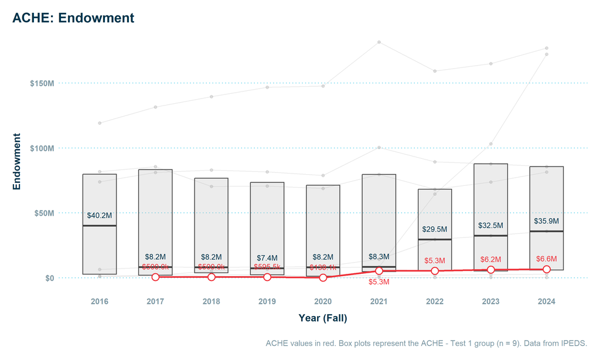

**12-Month Unduplicated Headcount**

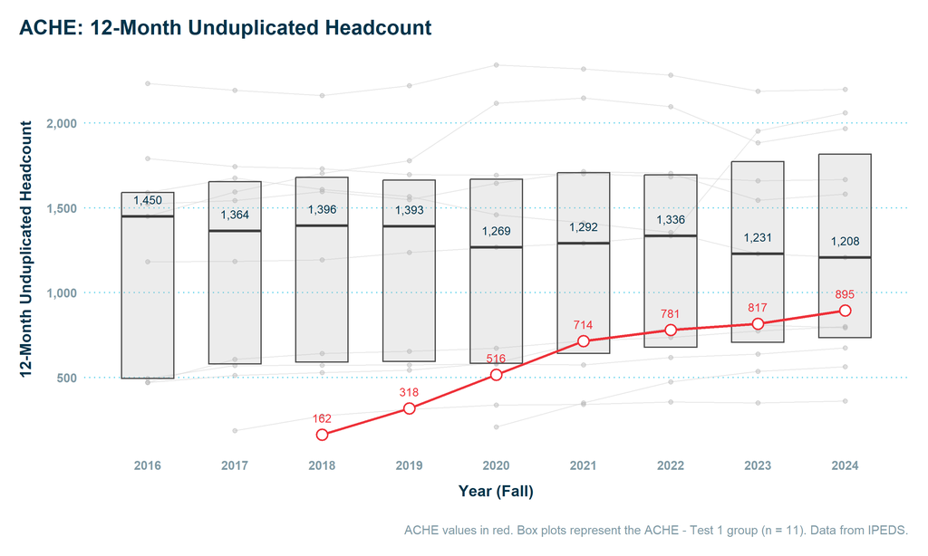

**Undergrad FTE**

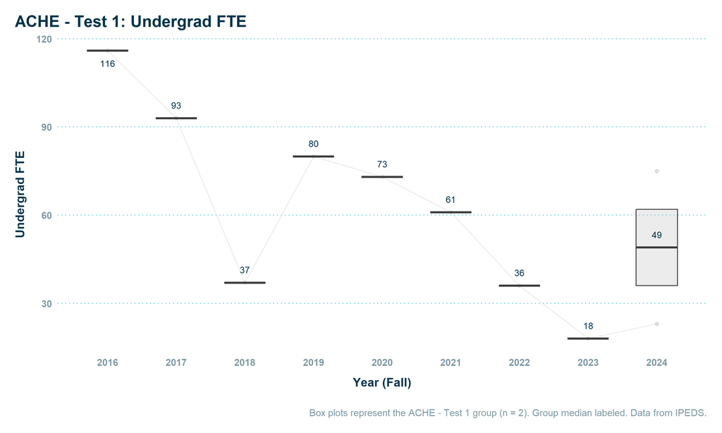

**Grad FTE**

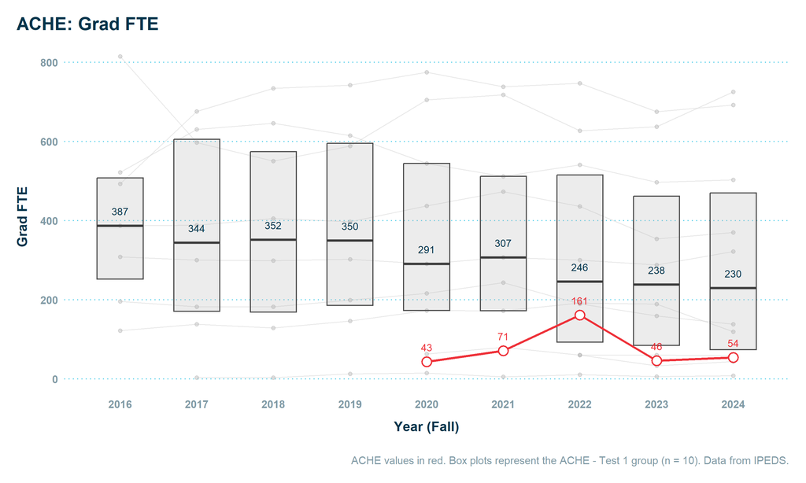

**Doc Prof Prac FTE**

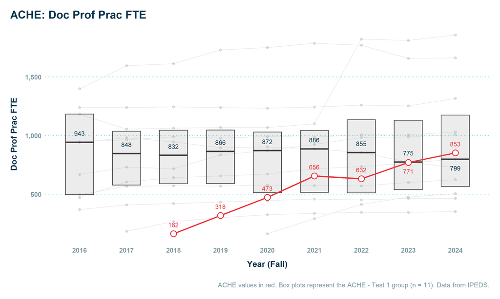

**Total FTE**

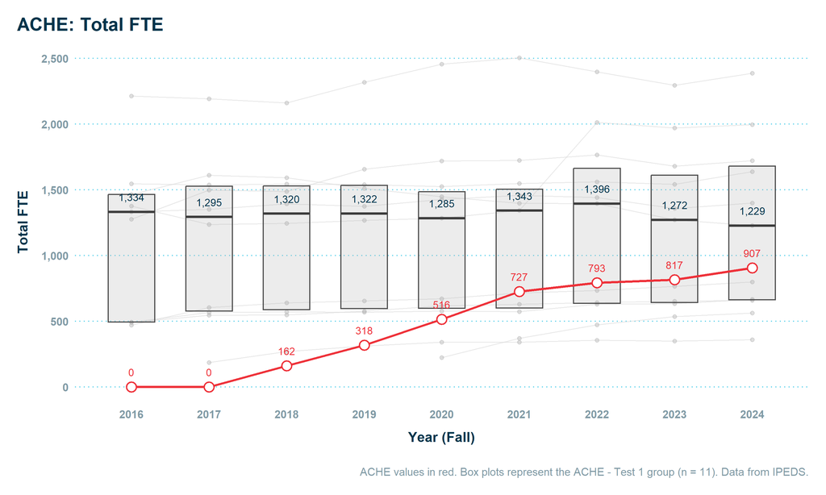

**Program Breadth (distinct 4-digit CIPs)**

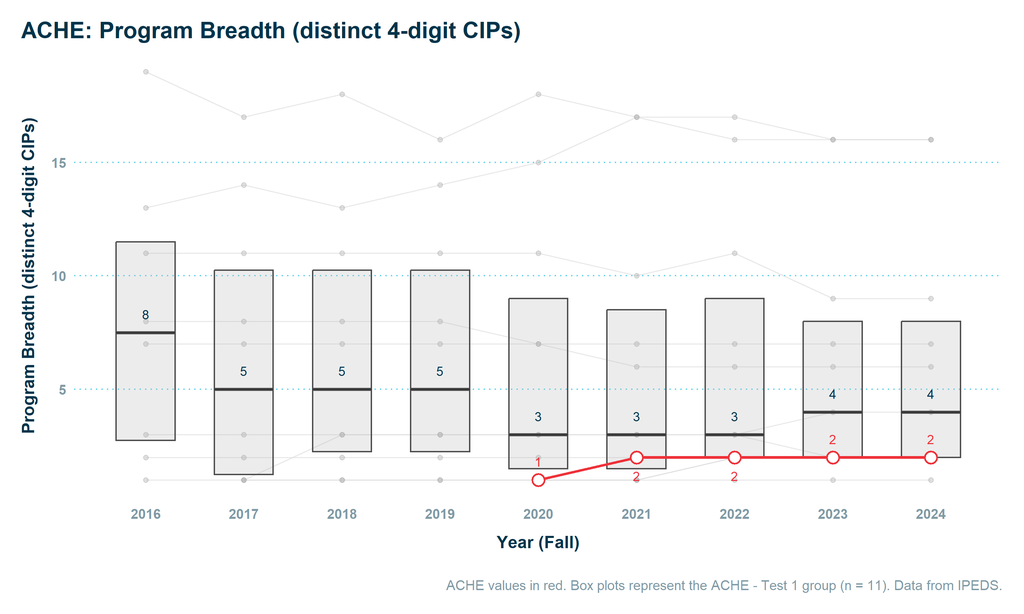

**Top 5 Programs % of Completions**

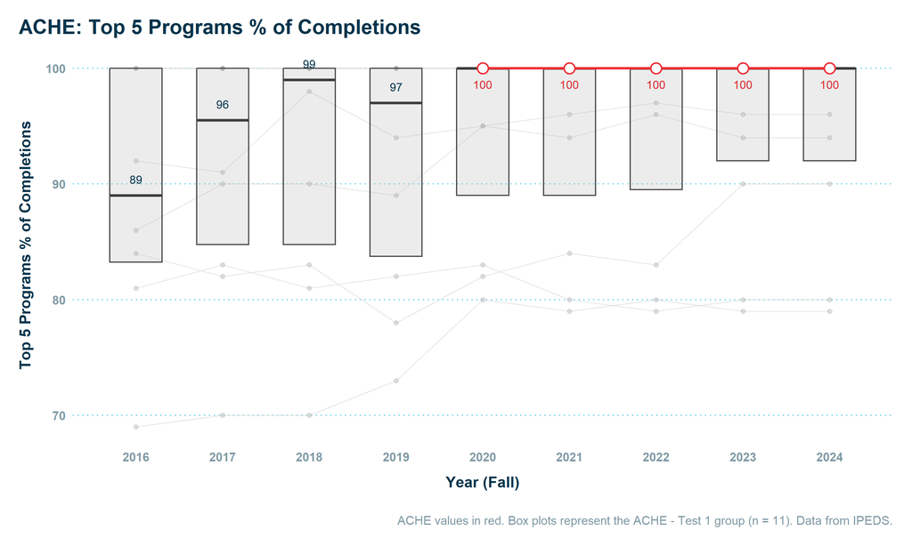

**Distinct Award Levels Offered**

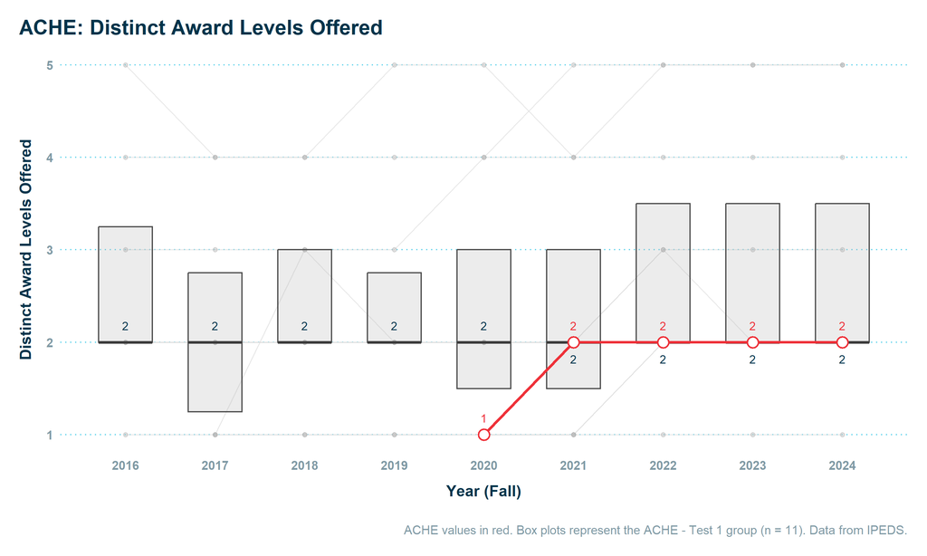

**ACHE - Test 2**

**Revenue**

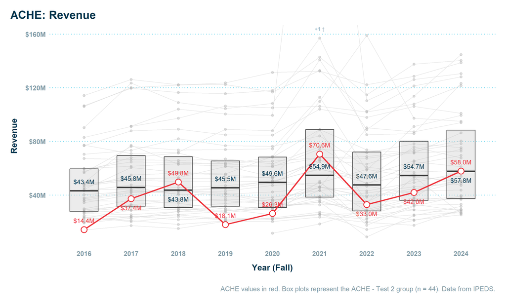

**Revenue from Tuition and Fees**

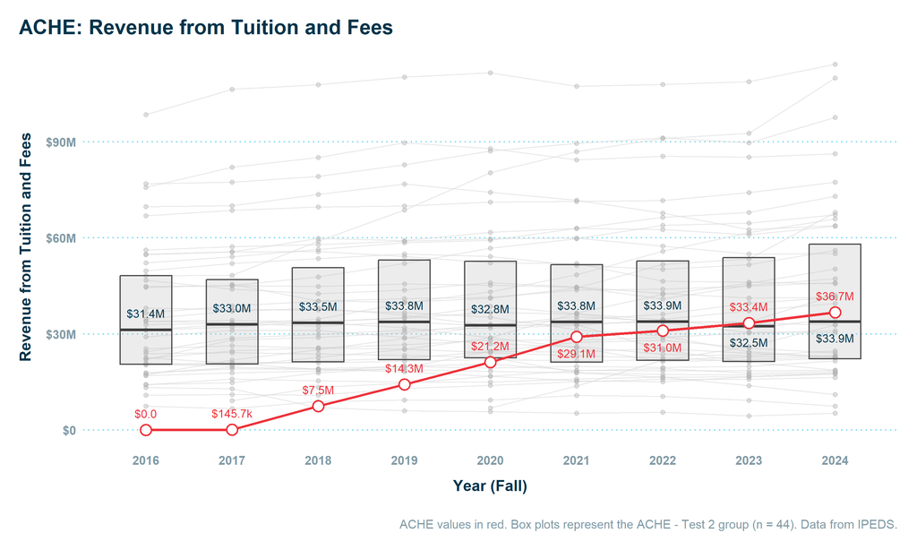

**Expenses**

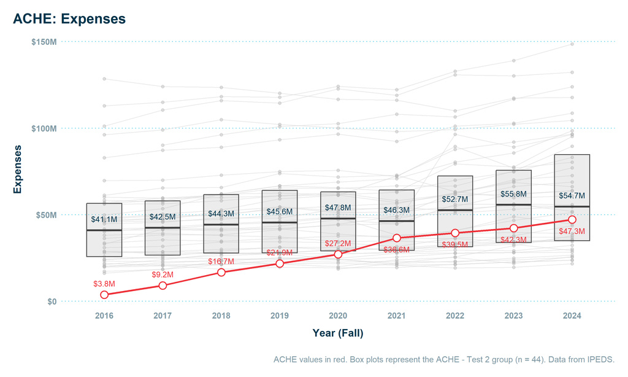

**Margin**

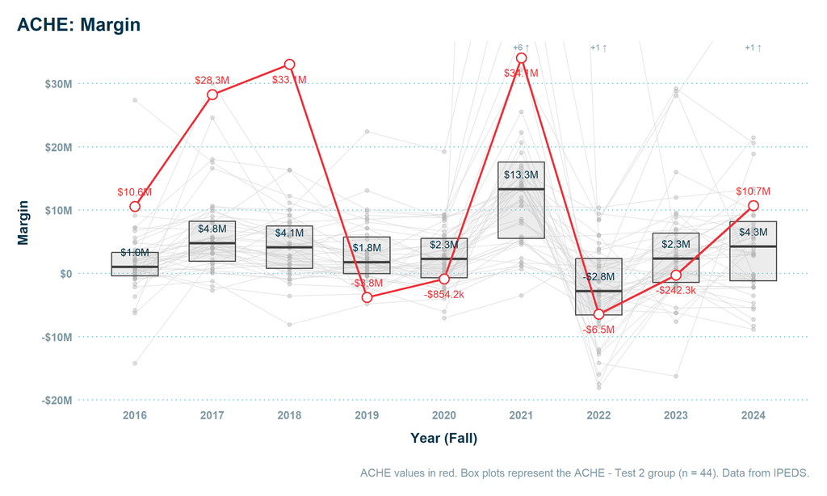

**Endowment**

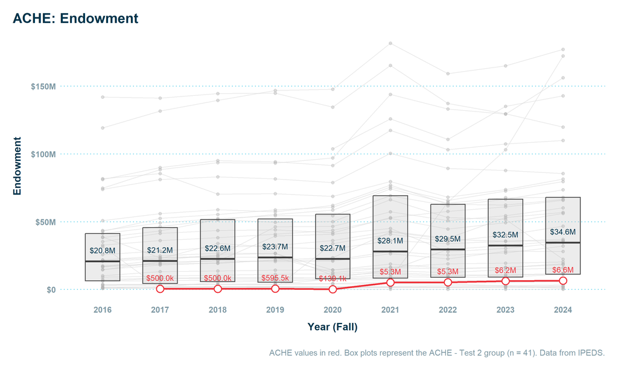

**12-Month Unduplicated Headcount**

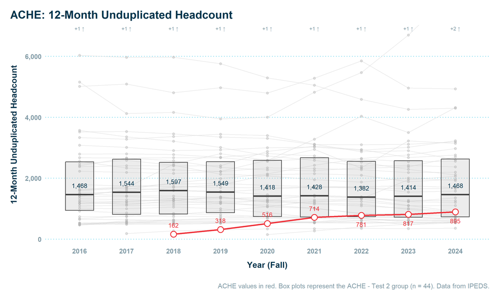

**Undergrad FTE**

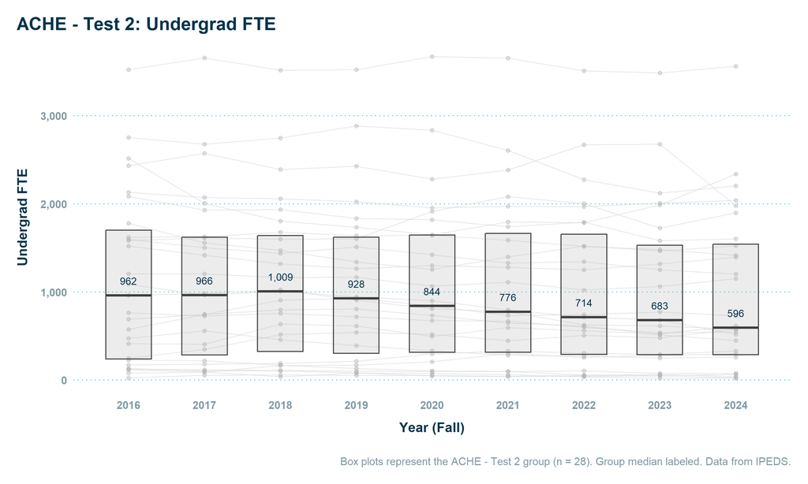

**Grad FTE**

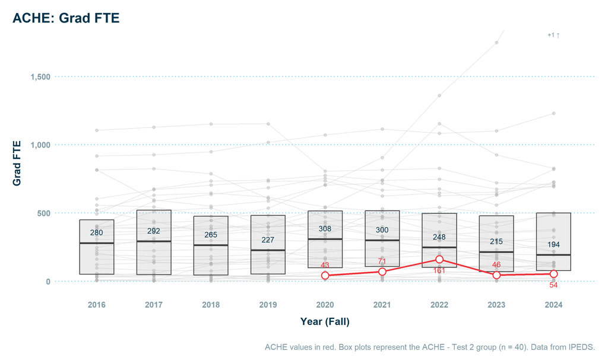

**Doc Prof Prac FTE**

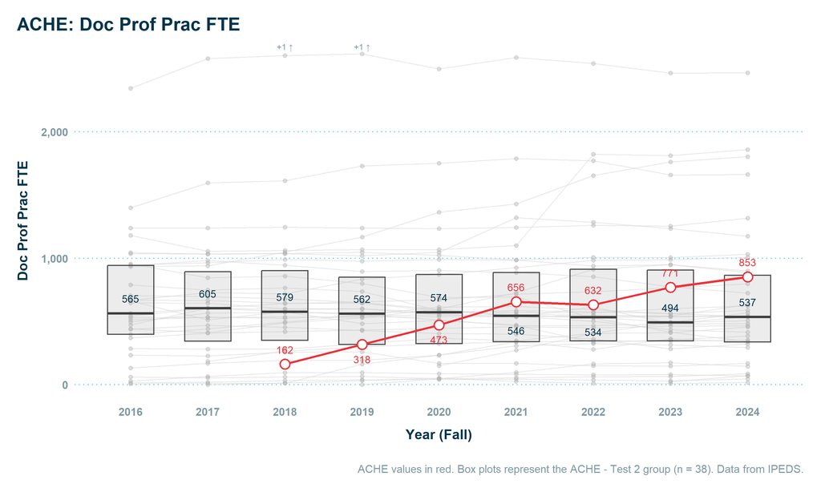

**Total FTE**

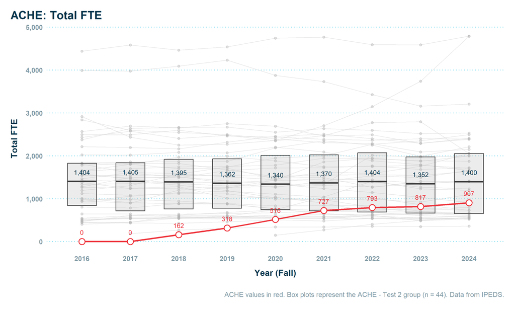

**Program Breadth (distinct 4-digit CIPs)**

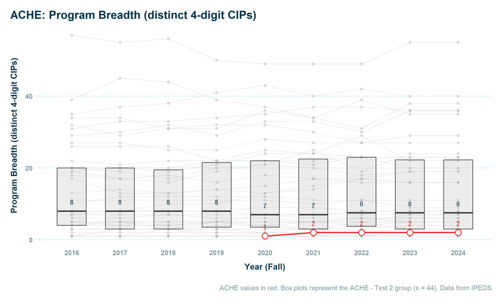

**Top 5 Programs % of Completions**

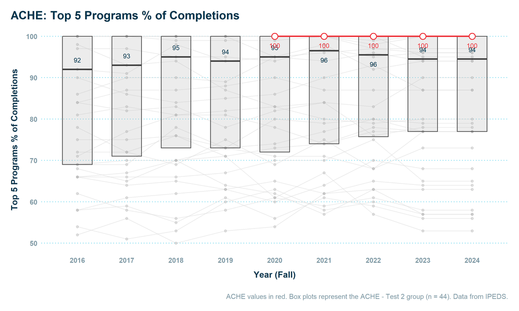

**Distinct Award Levels Offered**

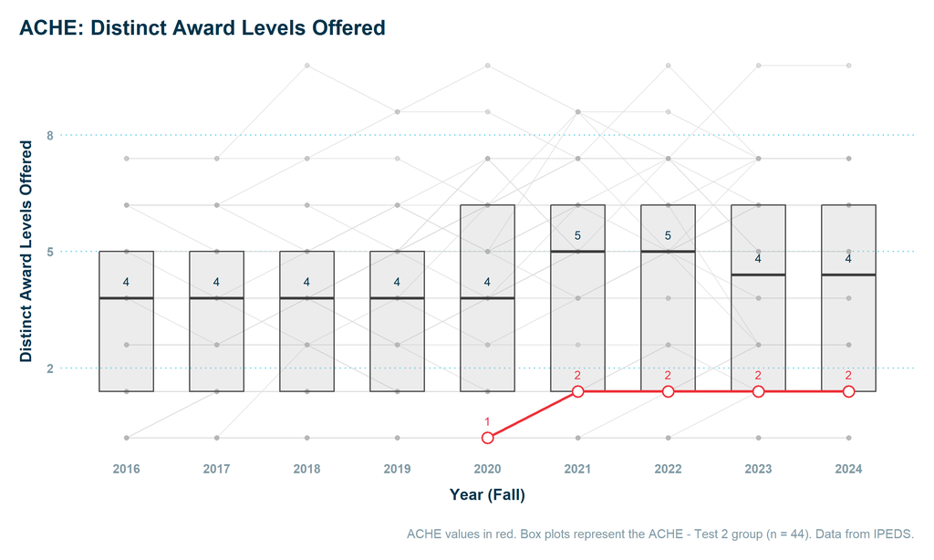

**ACHE - Test 3**

**Revenue**

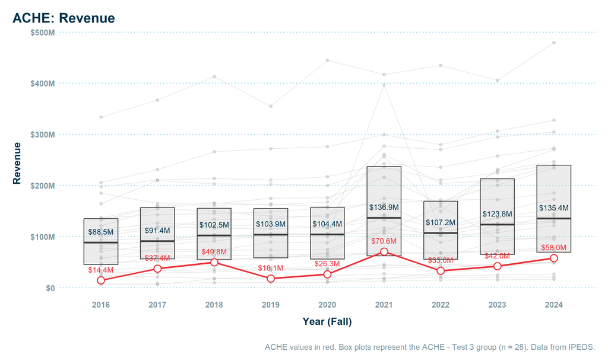

**Revenue from Tuition and Fees**

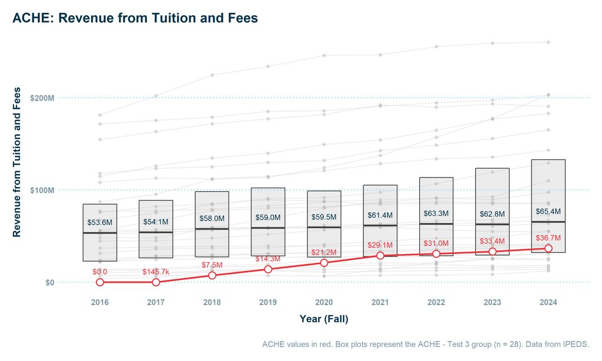

**Expenses**

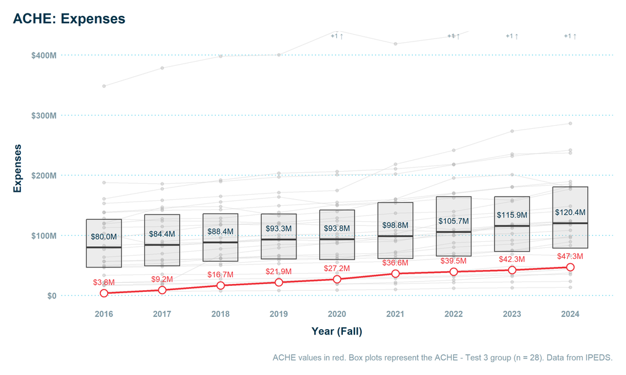

**Margin**

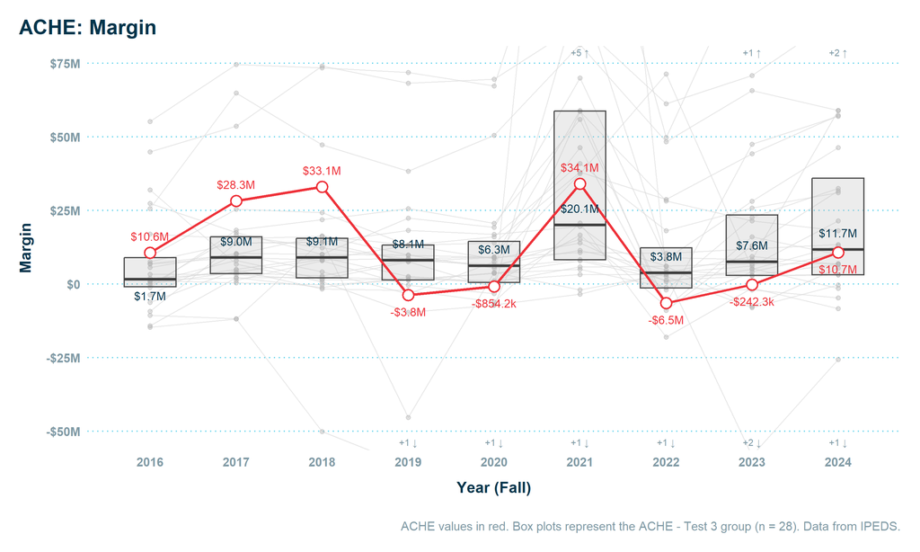

**Endowment**

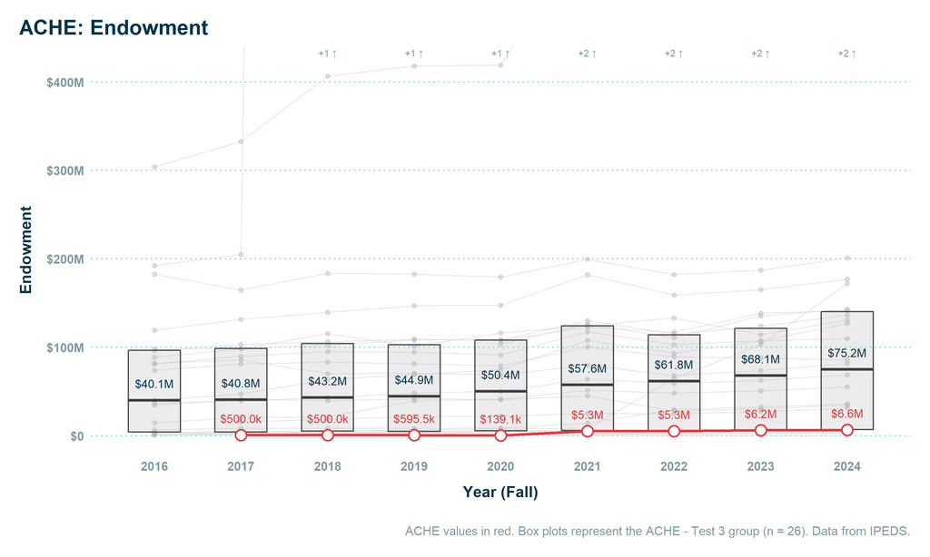

**12-Month Unduplicated Headcount**

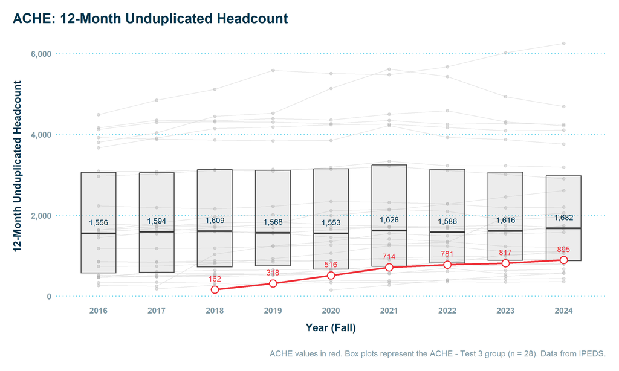

**Undergrad FTE**

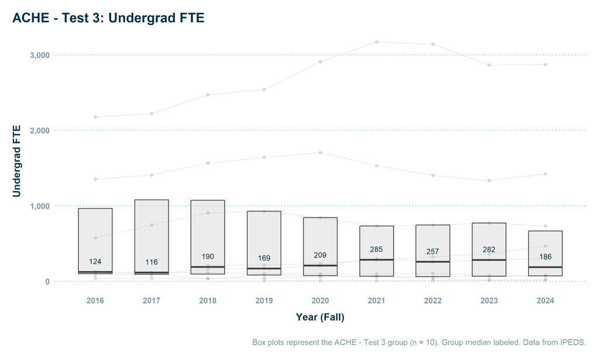

**Grad FTE**

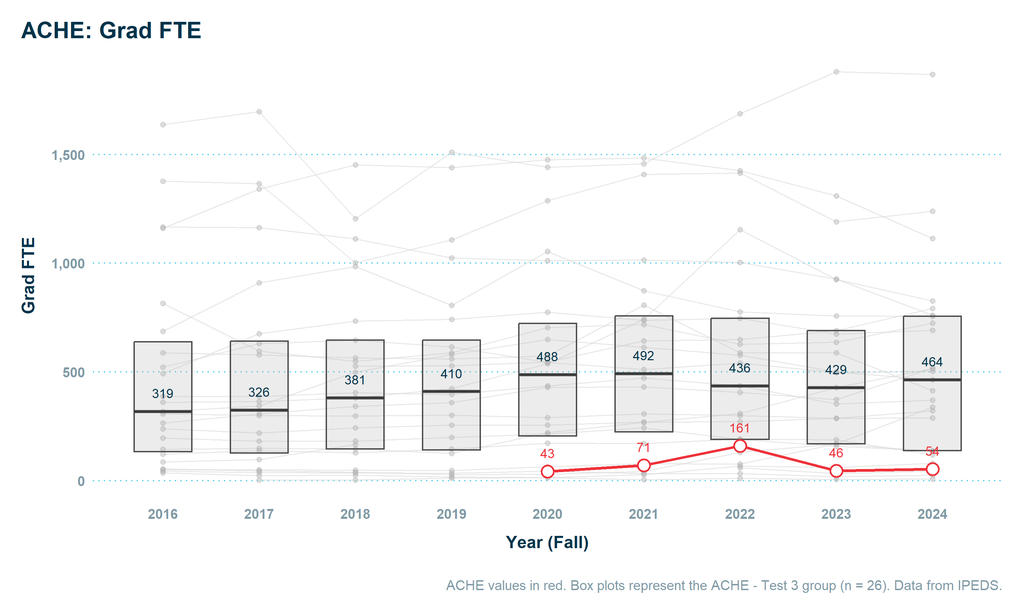

**Doc Prof Prac FTE**

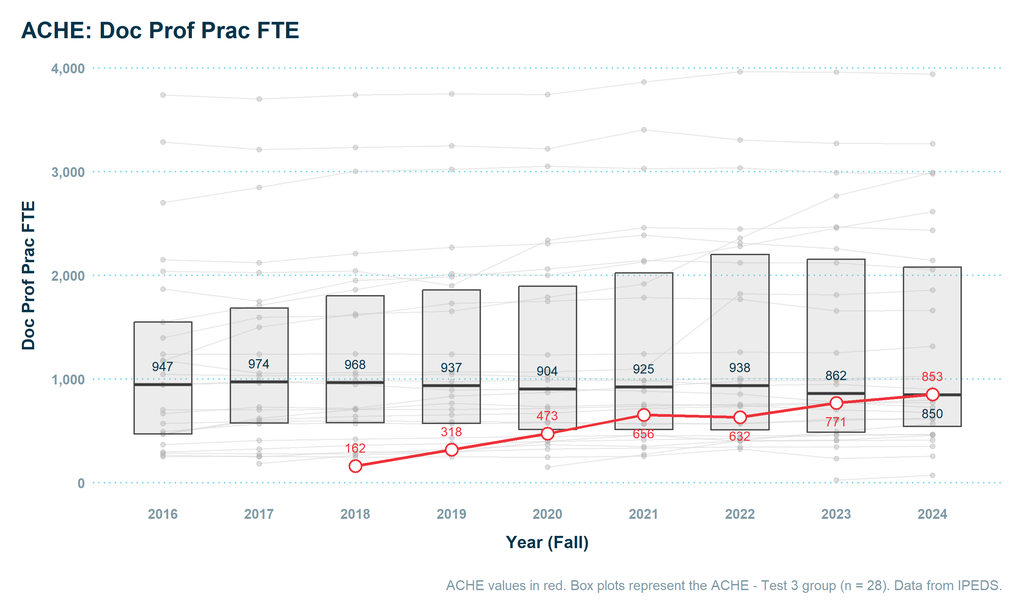

**Total FTE**

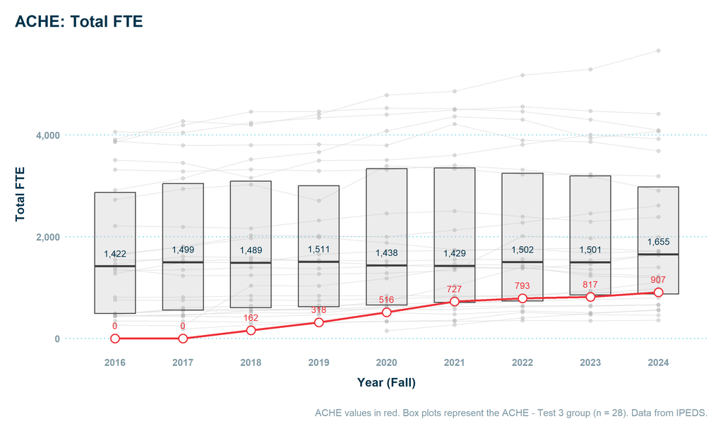

**Program Breadth (distinct 4-digit CIPs)**

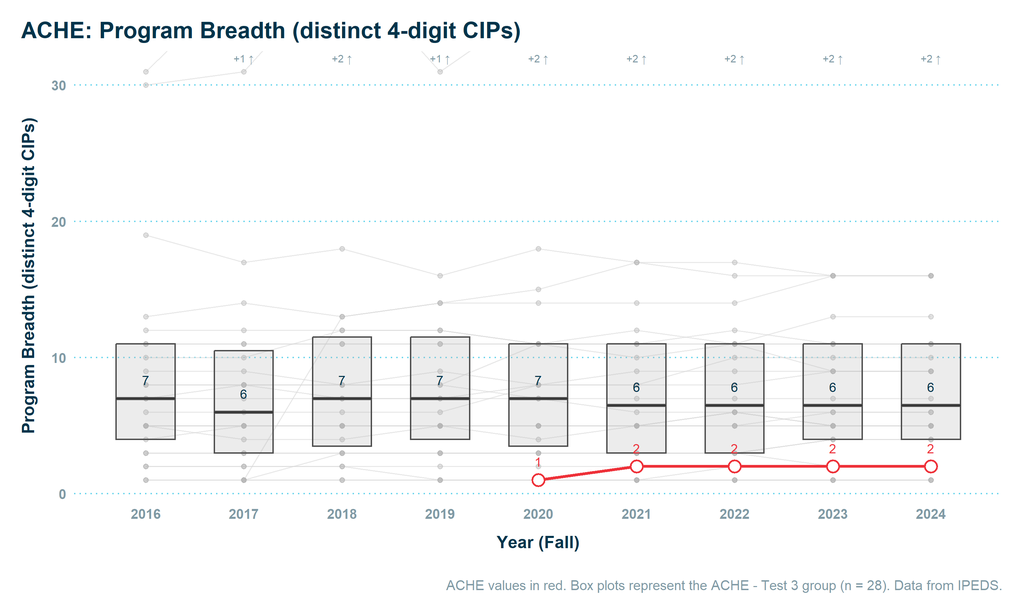

**Top 5 Programs % of Completions**

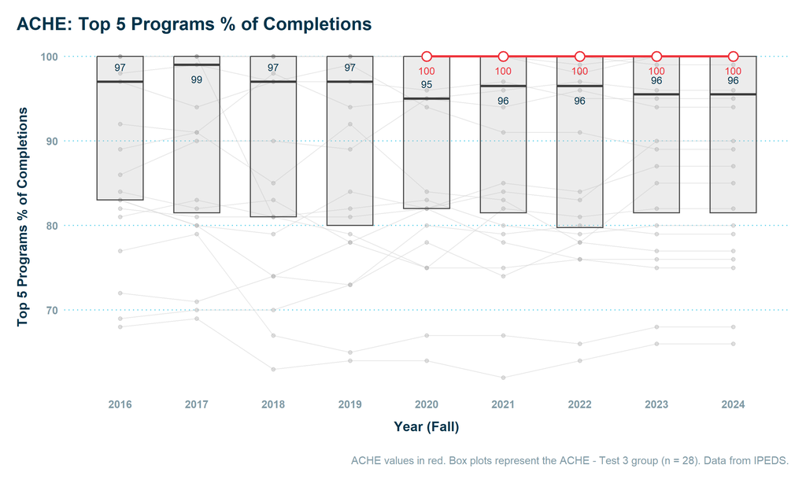

**Distinct Award Levels Offered**

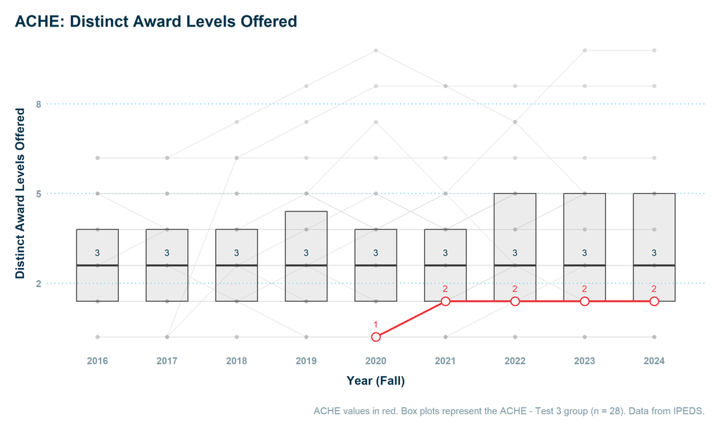

**COCA**

**Revenue**

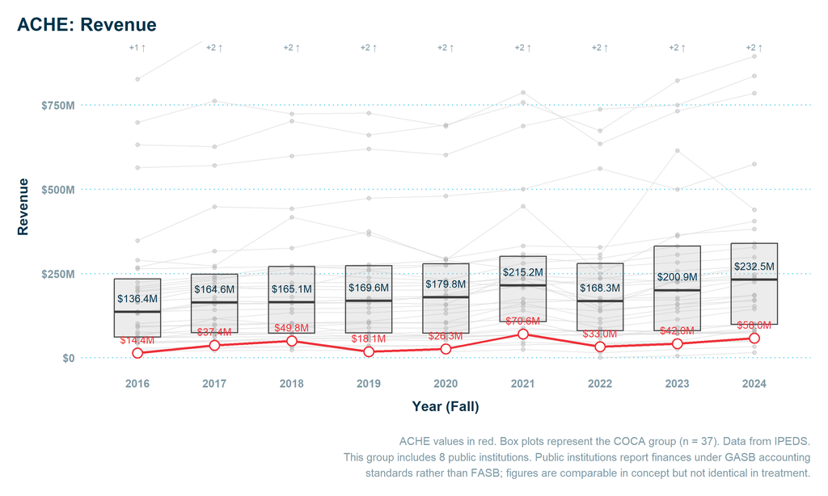

**Revenue from Tuition and Fees**

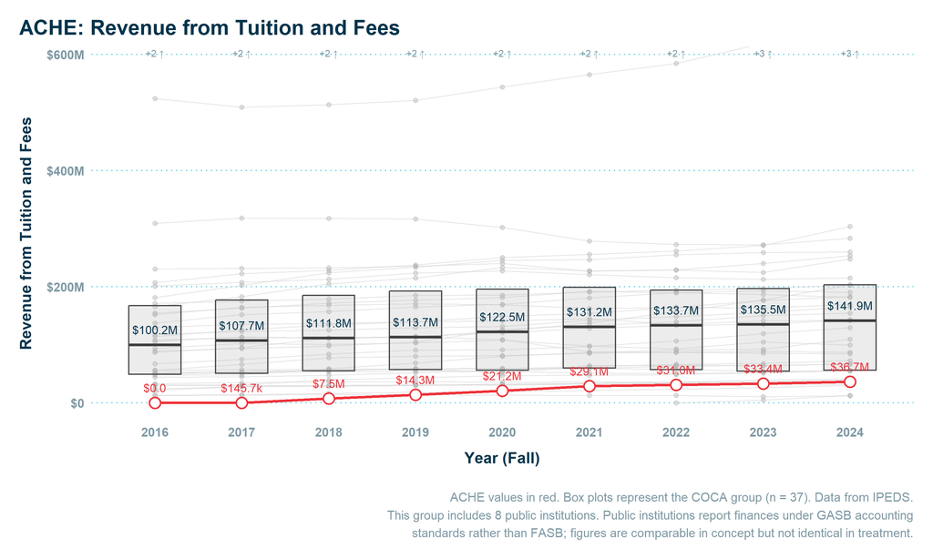

**Expenses**

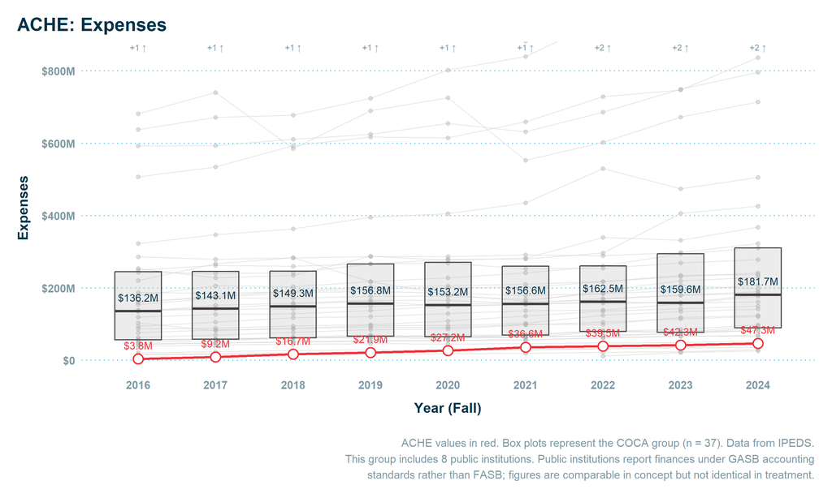

**Margin**

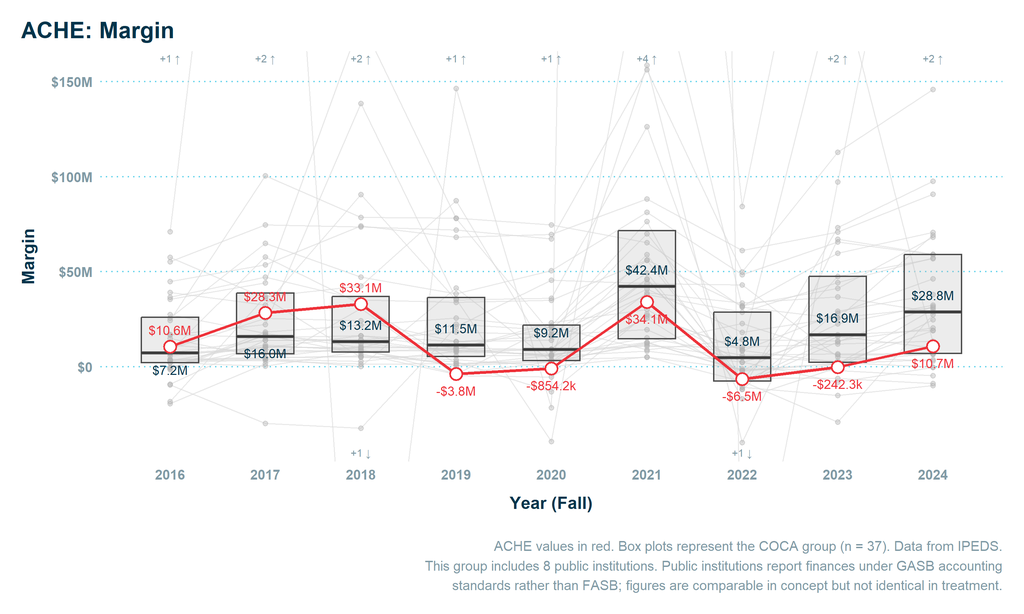

**Endowment**

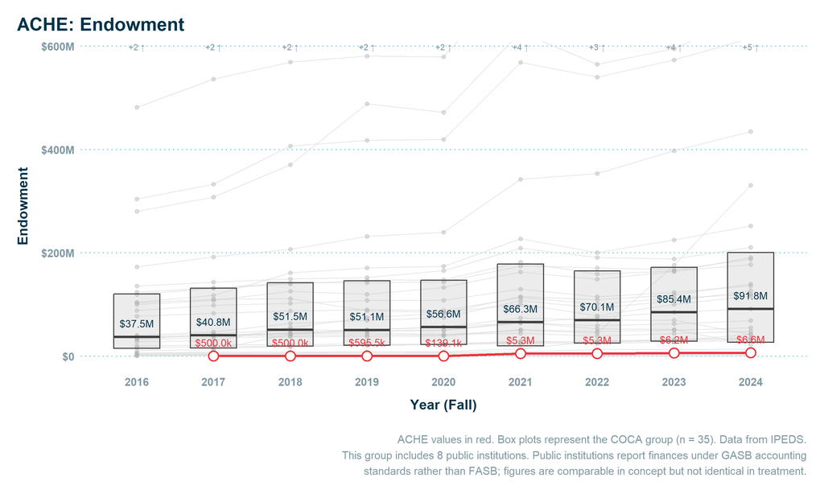

**12-Month Unduplicated Headcount**

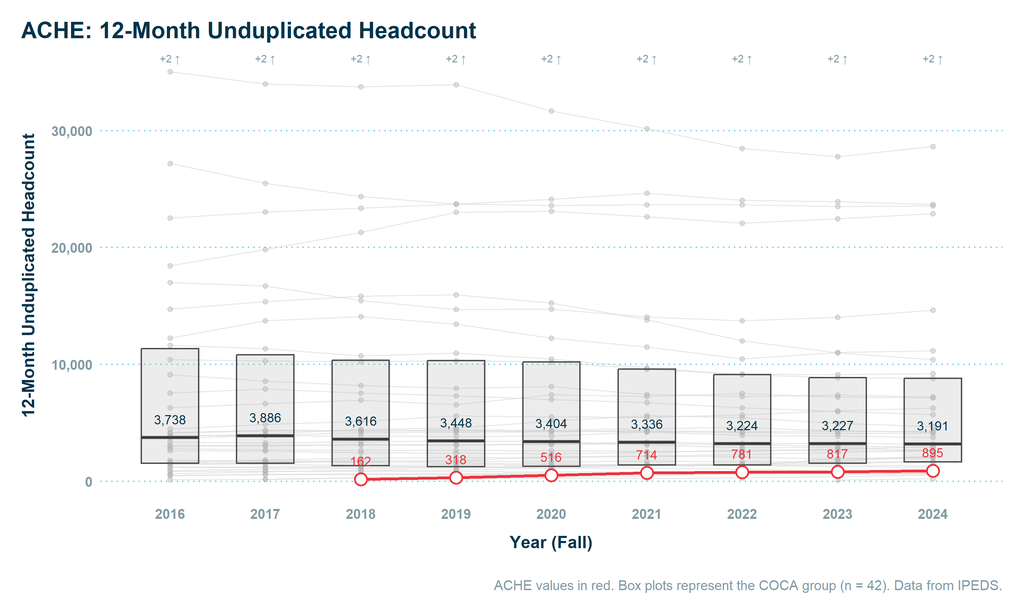

**Undergrad FTE**